# Answers-Netflix Challenge

Recommendation systems use rating data from many products and users to make recommendations for a specific user. Netflix uses a recommendation system to predict your ratings for a specific movie.

In October 2006, Netflix offered a challenge to the data science community: *improve our recommendation algorithm by 10% and win a million dollars*. In September 2009, [the winners were announced](http://bits.blogs.nytimes.com/2009/09/21/netflix-awards-1-million-prize-and-starts-a-new-contest/). You can read a good summary of how the winning algorithm was put together [here](http://blog.echen.me/2011/10/24/winning-the-netflix-prize-a-summary/), and a more detailed explanation [here](http://www.netflixprize.com/assets/GrandPrize2009_BPC_BellKor.pdf).

[figure not shown]

RMSE was the metric used to judge entries in the Netflix challenge. The lower the RMSE was on Netflix’s quiz set between the submittedrating predictions and the actual ratings, the better the method was. We will be using RMSE to evaluate our machine learning models in this homework as well.

$$\mbox{RMSE} = \sqrt{\frac{1}{N}\sum_{i=1}^N (\hat{Y}_i - Y_i)^2}$$

Download and load the [large training data set which is compressed](https://github.com/datasciencelabs/data/blob/master/movielens-train.csv.gz) into R. Train a machine learning model of you choice. You may wish to utilize a technique such as cross-validation to optimize any parameters associated with your model, and you may implement any modelling technique you feel comfortable with. This may include regression, regularization techniques, matrix decompositions (such as utilized by the winning team [here](http://www.netflixprize.com/assets/ProgressPrize2008_BellKor.pdf)), etc.

**Hint 1**: You can read in compressed file with `read_csv(gzfile(filename))`

**Hint 2**: Use the `RMSE()` function below to check your accuracy.

```r
RMSE <- function(true_ratings, predicted_ratings){
    sqrt(mean((true_ratings - predicted_ratings)^2))
}
```

Download the test data set available on GitHub [here](https://github.com/datasciencelabs/data/blob/master/movielens-test.csv.gz). Make predictions to fill in the `NA`s and save a file with the same format but with the ratings filled in to your repo. Submit this as a `.csv` file with your name in the file name (the file does not need to be compressed), along with the code you utilized to train the model, as part of your homework.

**Answer**

```r
mvtrain.df <-read_csv(gzfile('movielens-train.csv.gz'))
mvtest.df <- read_csv(gzfile('movielens-test.csv.gz'))
url <- "https://raw.githubusercontent.com/datasciencelabs/data/master/movies.csv"
movies <- movies <- read_csv(url)
```

Before predicting the user ratings for movies in the test dataset, it is important to know some basic information about the training data such as: a) the total number of users b) the total number of movies c) the distribution of the ratings d) summary data for the number of movies rated by a user (average, median, highest number)

```r
set.seed(755)
mvtrain.df %>% summarise(users_total = n_distinct(userId),
                         movies_total = n_distinct(movieId))
```

```
## # A tibble: 1 x 2
##   users_total movies_total
##         <int>        <int>
## 1      270896        44724
```

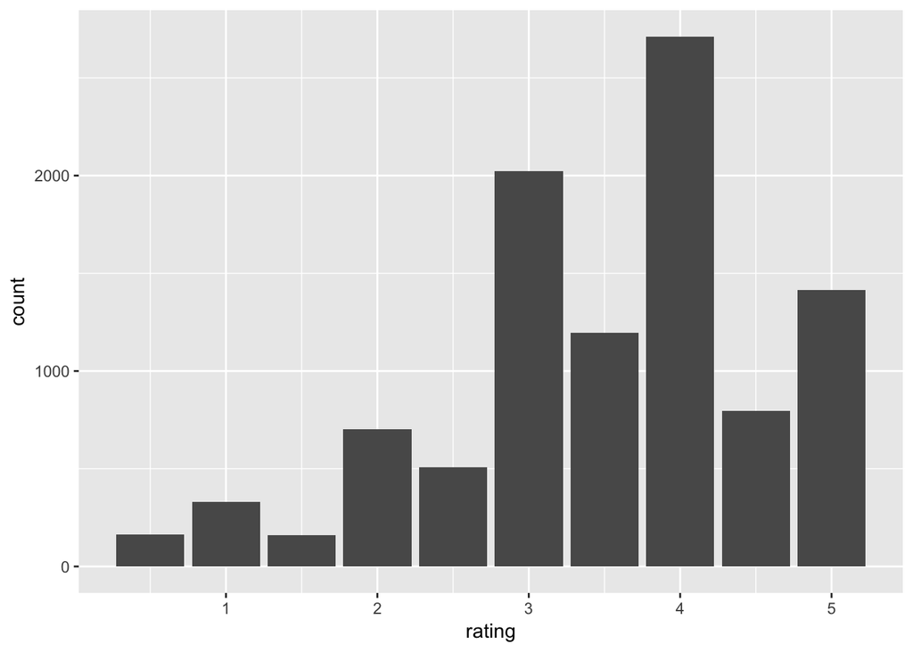

```r
#Plotting the rating distribution of a random sample of ratings (n=10000).
mvtrain.df %>% sample_n(10000) %>%
  ggplot(aes(x=rating)) +
  geom_bar()
```

```r
mvtrain.df %>% group_by(userId) %>%
  summarise(movies = n()) %>%
  summarise(mean = mean(movies),
            median = median(movies),
            max = max(movies))
```

```
## # A tibble: 1 x 3
##       mean median   max
##      <dbl>  <dbl> <dbl>
## 1 90.37653     28 17373
```

We have $i$ movies and $u$ users. To predict the rating for the $i$th movie rated b user $u$, we need to combine: a)$\mu$ - the average rating of all the movies in the training dataset b)$b_i$- the effect of the movie: this is the average ranking for a movie. This predictor is added in with the thought that each movie is ranked differently based on quality. c)$b_u$- the effect of the user: this represents the viewing preferences that a user possesses.

This can be done as follows:

```r
#Setting predictor 1, mu:
mu <- mean(mvtrain.df$rating)

#Setting predictor 2, bi:
lambda <- 30

movie_reg_means <- mvtrain.df %>%
  group_by(movieId) %>%
  summarize(b_i = sum(rating - mu)/(n()+lambda)) %>%
  left_join(movies)

#Setting predictor 3, bu:
lambda_2 <- 30

user_reg_means <- mvtrain.df %>%
  left_join(movie_reg_means) %>%
  mutate(resids = rating - mu - b_i) %>%
  group_by(userId) %>%
  summarize(b_u = sum(resids)/(n()+lambda_2))

join <- mvtest.df %>%
  left_join(movie_reg_means, by='movieId') %>%
  left_join(user_reg_means, by='userId') %>%
  replace_na(list(b_i=0, b_u=0))

predicted_ratings <- mu + join$b_i + join$b_u

mvtest.df[["rating"]] <- predicted_ratings

write.csv(mvtest.df, "hw6_sanjana.csv")
```